# Does better internet access promote economic well-being?

# Intro

Some hypotheses why Internet access in general could be important for economic growth

- digital services an increasingly larger part of the economy
- very innovative sector: higher returns?
- more efficient production functions

Or why this could not be

- digital services rarely create new products
- focus is on better production technologies
- big allocative and structural effects; costly adjustments

```r
broadband <- eurostat::get_eurostat(id = "isoc_r_broad_h")
```

```r
income    <- eurostat::get_eurostat(id = "tgs00005")
```

## Data

To answer this question, I obtained data about regional income and broadband internet access from [Eurostat](http://ec.europa.eu/eurostat). The data comprises a yearly panel that runs from 2004 to 2015 for income and from 2006 to 2016 for broadband data.

For simplicity, I take a first glance at the most recent data and visualise the distribution across European NUTS2 and NUTS3 regions.

```r
income_2015 <- income %>%
  dplyr::filter(time == "2015-01-01") %>%
  dplyr::select(-c(unit, time))
income_map_data <- income_2015 %>%
  dplyr::mutate(cat = cut_to_classes(values, 7, style = "quantile")) %>%
  eurostat::merge_eurostat_geodata(output_class = "spdf")
```

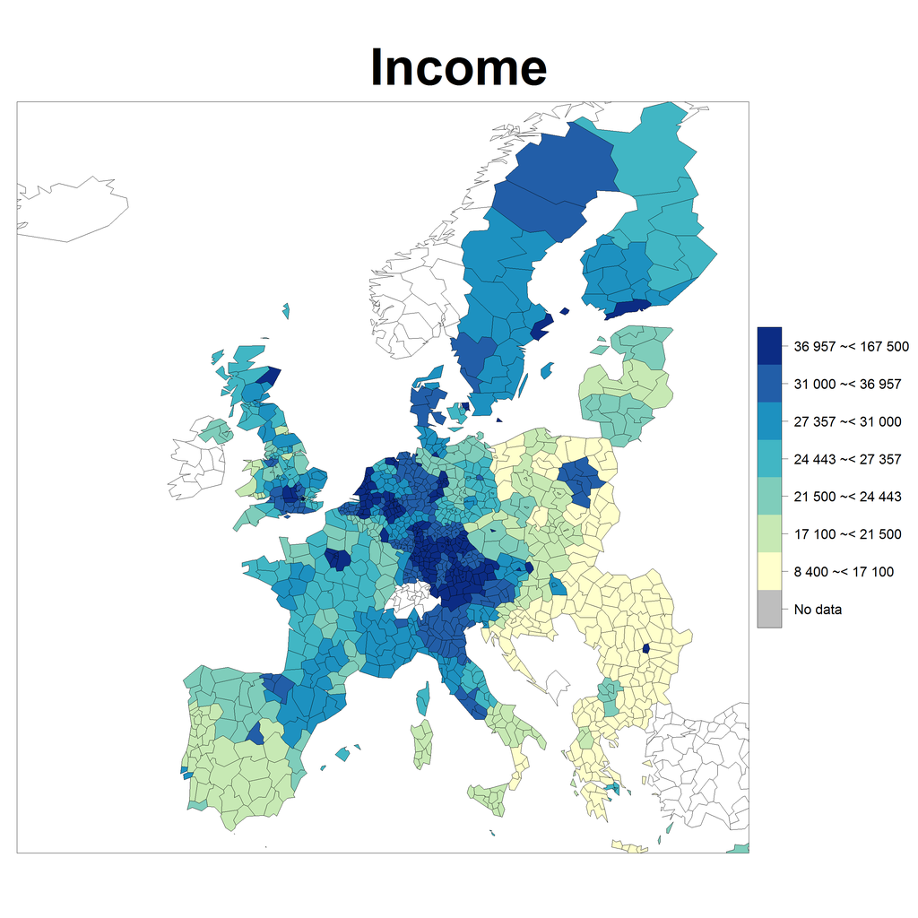

```r
fig <- sp::spplot(
  main=list(label="Income",cex=3),
  income_map_data, "cat",
  xlim = c(-22, 34), ylim = c(35, 70),
  col.regions = c("grey", colours)
)
update(fig, par.settings = list(fontsize = list(text = 40)))
```

```r
broadband_2014 <- broadband %>%
  dplyr::filter(time == "2014-01-01",
                unit == "PC_HH",
                nchar(as.character(geo)) >= 3) %>%
  dplyr::select(-c(unit, time))
bb_map_data <- broadband_2014 %>%
  dplyr::mutate(cat = cut_to_classes(values, 7, style = "jenks")) %>%
  eurostat::merge_eurostat_geodata(output_class = "spdf")
```

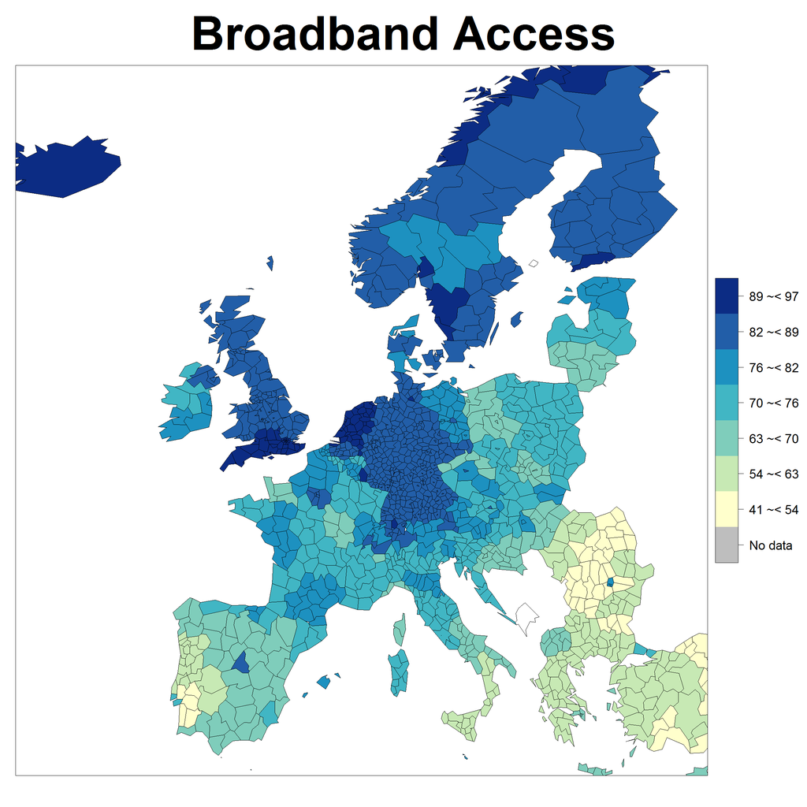

```r
fig <- sp::spplot(
  main=list(label="Broadband Access",cex=3),
  bb_map_data, "cat",
  xlim = c(-22, 34), ylim = c(35, 70),
  col.regions = c("grey", colours)
)
update(fig, par.settings = list(fontsize = list(text = 35)))
```

## The nexus betwen Income and Internet Access

Here is a scatter plot showing the regions for which data was available in 2015 for income and in 2014 for broadband access. There is a clear positive relationship. However, this could be driven by a multitude of confounders and the relationship is riddled with reverse causality. The results below therefore only point to a fairly strong correlation without any causal implications.

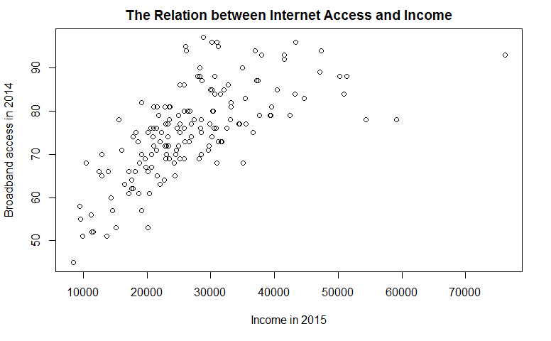

```r
data <- dplyr::inner_join(broadband_2014, income_2015, by = "geo") %>%
  dplyr::rename(broadband = values.x, income = values.y)
plot(y = data$broadband, data$income,
     main = "The Relation between Internet Access and Income",
     xlab = "Income in 2015",
     ylab = "Broadband access in 2014")
```